# Operating Model Comparison Report

ABT-MSE

Tom Carruthers

February 14, 2022

# 1 Introduction / notes

A comparison report for reference grid OMs with length composition weighting of 1/20 (factor level L)

# 2 OM design

## 2.1 Factor 1: Regime shift

| 1: West: h=0.6 to h=0.9 1975+, East: h=0.98 for 1987- to h=0.98 1988+ |
| --- |
| 2: West: B-H h=0.6 all years, East: B-H h=0.7 all years |
| 3: West: post 75+ changes to pre ’75 after 10 yrs, East: 88+ to ’50-87 after 10 years |

## 2.2 Factor 2: Natural Mortality / Maturity

| A: Younger spawning, High M |
| --- |
| B: Older spawning, Low M |

## 2.3 Factor 3: Scale

| –: mean SSB 15kt West, 200kt East |
| --- |
| -+: mean SSB 15kt West, 400kt East |
| +-: mean SSB 50kt West, 200kt East |
| ++: mean SSB 50kt West, 400kt East |

## 2.4 Factor 4: Length composition weighting

| L: Low length composition weight of 1/20 |
| --- |
| H: High length composition weight of 1 |

# 3 OMs presented in this report

Table 1. The subset of wider operating models included in this comparison report.

|  | Code. | Regime shift | Maturity / M | Scale | Length Comp wt |
| --- | --- | --- | --- | --- | --- |
| 1 | 1 A – L | 1 | A | – | L |
| 2 | 2 A – L | 2 | A | – | L |
| 4 | 1 B – L | 1 | B | – | L |
| 5 | 2 B – L | 2 | B | – | L |
| 7 | 1 A -+ L | 1 | A | -+ | L |
| 8 | 2 A -+ L | 2 | A | -+ | L |
| 10 | 1 B -+ L | 1 | B | -+ | L |
| 11 | 2 B -+ L | 2 | B | -+ | L |
| 13 | 1 A +- L | 1 | A | +- | L |
| 14 | 2 A +- L | 2 | A | +- | L |
| 16 | 1 B +- L | 1 | B | +- | L |
| 17 | 2 B +- L | 2 | B | +- | L |
| 19 | 1 A ++ L | 1 | A | ++ | L |
| 20 | 2 A ++ L | 2 | A | ++ | L |
| 22 | 1 B ++ L | 1 | B | ++ | L |
| 23 | 2 B ++ L | 2 | B | ++ | L |

# 4 Reference points

## 4.1 Eastern stock

Table 2. Reference points for the Eastern stock using 2019 stock-recruitment (R0 and steepness). Tabulated biomass numbers (BMSY, BMSY_B0) refer to spawning biomass. These biomass numbers and MSY numbers are expressed in thousands of tonnes. Depletion is spawning biomass in 2019 relative to the ‘dynamic B0’ (the spawning biomass under zero fishing accounting for shifts in recruitment).

| OM | Code | MSY | BMSY | BMSY_B0 | B_BMSY | Dep |
| --- | --- | --- | --- | --- | --- | --- |
| 1 | 1 A – L | 88120 | 743478 | 0.338 | 0.957 | 0.324 |
| 2 | 2 A – L | 26209 | 413649 | 0.301 | 1.133 | 0.341 |
| 4 | 1 B – L | 89581 | 820123 | 0.381 | 0.82 | 0.312 |
| 5 | 2 B – L | 25060 | 337265 | 0.351 | 1.254 | 0.44 |
| 7 | 1 A -+ L | 73629 | 682449 | 0.262 | 1.872 | 0.491 |
| 8 | 2 A -+ L | 28103 | 471476 | 0.302 | 1.324 | 0.4 |
| 10 | 1 B -+ L | 77432 | 795790 | 0.291 | 1.296 | 0.377 |
| 11 | 2 B -+ L | 21168 | 391419 | 0.29 | 1.046 | 0.303 |
| 13 | 1 A +- L | 53940 | 519520 | 0.271 | 0.908 | 0.246 |
| 14 | 2 A +- L | 21753 | 338007 | 0.325 | 1.062 | 0.345 |
| 16 | 1 B +- L | 65679 | 664354 | 0.297 | 1.146 | 0.34 |
| 17 | 2 B +- L | 25603 | 363662 | 0.353 | 1.233 | 0.435 |
| 19 | 1 A ++ L | 79292 | 743653 | 0.269 | 1.922 | 0.517 |
| 20 | 2 A ++ L | 34455 | 544959 | 0.325 | 1.128 | 0.366 |
| 22 | 1 B ++ L | 77928 | 811893 | 0.292 | 1.224 | 0.357 |
| 23 | 2 B ++ L | 28436 | 429418 | 0.343 | 1.261 | 0.433 |

## 4.2 Western stock

Table 3. As Table 2 but for the Western stock.

| OM | Code | MSY | BMSY | BMSY_B0 | B_BMSY | Dep |
| --- | --- | --- | --- | --- | --- | --- |
| 1 | 1 A – L | 1078 | 13361 | 0.292 | 0.503 | 0.147 |
| 2 | 2 A – L | 983 | 17497 | 0.358 | 0.477 | 0.171 |
| 4 | 1 B – L | 1262 | 10622 | 0.265 | 0.394 | 0.104 |
| 5 | 2 B – L | 1297 | 23655 | 0.363 | 0.385 | 0.14 |
| 7 | 1 A -+ L | 1150 | 13640 | 0.296 | 0.493 | 0.146 |
| 8 | 2 A -+ L | 978 | 17963 | 0.36 | 0.488 | 0.176 |
| 10 | 1 B -+ L | 1375 | 11639 | 0.27 | 0.366 | 0.099 |
| 11 | 2 B -+ L | 954 | 16173 | 0.349 | 0.489 | 0.171 |
| 13 | 1 A +- L | 985 | 14733 | 0.3 | 1.459 | 0.438 |
| 14 | 2 A +- L | 997 | 23501 | 0.368 | 0.762 | 0.28 |
| 16 | 1 B +- L | 1132 | 10232 | 0.265 | 1.128 | 0.299 |
| 17 | 2 B +- L | 1146 | 24325 | 0.365 | 0.655 | 0.239 |
| 19 | 1 A ++ L | 1381 | 16585 | 0.293 | 1.14 | 0.334 |
| 20 | 2 A ++ L | 783 | 15660 | 0.362 | 1.019 | 0.369 |
| 22 | 1 B ++ L | 1175 | 10995 | 0.269 | 1.376 | 0.37 |
| 23 | 2 B ++ L | 1067 | 22576 | 0.363 | 0.67 | 0.243 |

# 5 Comparison of global likelihoods

Table 4. These are weighted negative log-likelihoods. Color coding is by column. Rows with all black values depict models that did not converge.

| OM | Code | Cat | CR | Surv | Comp | SOOm | SOOg | Tag | Rec | Mov | Sel | SRA | R0diff | MI | SPr | TOT_nP | TOT |
| --- | --- | --- | --- | --- | --- | --- | --- | --- | --- | --- | --- | --- | --- | --- | --- | --- | --- |
| 1 | 1 A – L | 163 | 503 | 1089 | 1268 | 562 | 177 | 2446 | 31 | 316 | 129 | 0 | 16 | 52 | 47 | 6255 | 6800 |
| 2 | 2 A – L | 208 | 486 | 1278 | 1252 | 430 | 146 | 2512 | 81 | 317 | 127 | 0 | 0 | 50 | -4 | 6308 | 6883 |
| 4 | 1 B – L | 77 | 491 | 1174 | 1142 | 553 | 174 | 2435 | 31 | 310 | 128 | 2 | 13 | 51 | 34 | 6079 | 6615 |
| 5 | 2 B – L | 90 | 493 | 1306 | 1218 | 355 | 128 | 2660 | 68 | 315 | 126 | 6 | 0 | 46 | 26 | 6277 | 6838 |
| 7 | 1 A -+ L | 128 | 488 | 1080 | 1198 | 493 | 174 | 2439 | 38 | 320 | 129 | 0 | 14 | 55 | -13 | 5987 | 6542 |
| 8 | 2 A -+ L | 162 | 490 | 1202 | 1254 | 446 | 150 | 2512 | 79 | 319 | 127 | 0 | 0 | 53 | -10 | 6206 | 6783 |
| 10 | 1 B -+ L | 62 | 468 | 1122 | 1156 | 500 | 175 | 2425 | 32 | 314 | 128 | 3 | 11 | 54 | -15 | 5892 | 6434 |
| 11 | 2 B -+ L | 150 | 463 | 1195 | 1292 | 405 | 139 | 2538 | 49 | 310 | 129 | 6 | 0 | 63 | 18 | 6201 | 6757 |
| 13 | 1 A +- L | -7 | 426 | 1129 | 1214 | 390 | 128 | 2393 | 24 | 311 | 129 | 0 | 15 | 39 | 11 | 5683 | 6201 |
| 14 | 2 A +- L | 123 | 483 | 1206 | 1224 | 410 | 137 | 2593 | 66 | 306 | 128 | 0 | 0 | 43 | 13 | 6190 | 6734 |
| 16 | 1 B +- L | 46 | 512 | 1332 | 1116 | 510 | 154 | 2378 | 34 | 306 | 129 | 0 | 15 | 46 | 29 | 6077 | 6607 |
| 17 | 2 B +- L | 71 | 487 | 1306 | 1222 | 340 | 119 | 2624 | 69 | 312 | 127 | 1 | 0 | 44 | 22 | 6191 | 6744 |
| 19 | 1 A ++ L | 63 | 517 | 1304 | 1160 | 415 | 151 | 2378 | 44 | 314 | 129 | 0 | 18 | 46 | -17 | 5971 | 6521 |
| 20 | 2 A ++ L | 113 | 457 | 1282 | 1252 | 446 | 138 | 2432 | 73 | 314 | 127 | 0 | 0 | 52 | 8 | 6127 | 6694 |
| 22 | 1 B ++ L | 19 | 513 | 1285 | 1133 | 414 | 146 | 2373 | 43 | 311 | 129 | 0 | 13 | 46 | -17 | 5865 | 6408 |
| 23 | 2 B ++ L | 36 | 477 | 1256 | 1216 | 404 | 138 | 2518 | 60 | 307 | 128 | 2 | 0 | 44 | 8 | 6052 | 6593 |

Cat = catch data by fleet, quarter and area. CR = the fishery dependent catch rate (CPUE) indices, Surv = fishery-independent survey indices, Comp = length composition data, SOOm = stock of origin microchemistry data, SOOg = stock of origin genetics, Tag = Electronic tagging data, Rec = prior on recruitment deviations, Mov = prior on movement parameters, Sel = prior on size selectivity parameters, SRA = penalty incurred when catches exceed F=1 catches in the stock reduction analysis phase (1864-1964), MI = a prior on similarity to the ‘Master Index’ that predicts F by year, area, season and fleet, R0diff = a prior on the difference in R0 estimated in two-phase recruitment models (recruitment level 1 and 3), SPr = seasonal distribution prior, TOT_nP = total global objective function without priors, TOT = total global objective function.

Table 5. These are weighted negative log-likelihoods expressed as differences from the base-case weighting. Color coding is by column. Rows with all black values depict models that did not converge.

| OM | Code | Cat | CR | Surv | Comp | SOOm | SOOg | Tag | Rec | Mov | Sel | SRA | R0diff | MI | SPr | TOT_nP | TOT |
| --- | --- | --- | --- | --- | --- | --- | --- | --- | --- | --- | --- | --- | --- | --- | --- | --- | --- |
| 1 | 1 A – L | 0 | 0 | 0 | 0 | 0 | 0 | 0 | 0 | 0 | 0 | 0 | 0 | 0 | 0 | 0 | 6800 |
| 2 | 2 A – L | 45 | -17 | 189 | -16 | -132 | -31 | 66 | 50 | 1 | -2 | 0 | -16 | -2 | -51 | 53 | 6883 |
| 4 | 1 B – L | -86 | -12 | 85 | -126 | -9 | -3 | -11 | 0 | -6 | -1 | 2 | -3 | -1 | -13 | -176 | 6615 |
| 5 | 2 B – L | -73 | -10 | 217 | -50 | -207 | -49 | 214 | 37 | -1 | -3 | 6 | -16 | -6 | -21 | 22 | 6838 |
| 7 | 1 A -+ L | -35 | -15 | -9 | -70 | -69 | -3 | -7 | 7 | 4 | 0 | 0 | -2 | 3 | -60 | -268 | 6542 |
| 8 | 2 A -+ L | -1 | -13 | 113 | -14 | -116 | -27 | 66 | 48 | 3 | -2 | 0 | -16 | 1 | -57 | -49 | 6783 |
| 10 | 1 B -+ L | -101 | -35 | 33 | -112 | -62 | -2 | -21 | 1 | -2 | -1 | 3 | -5 | 2 | -62 | -363 | 6434 |
| 11 | 2 B -+ L | -13 | -40 | 106 | 24 | -157 | -38 | 92 | 18 | -6 | 0 | 6 | -16 | 11 | -29 | -54 | 6757 |
| 13 | 1 A +- L | -170 | -77 | 40 | -54 | -172 | -49 | -53 | -7 | -5 | 0 | 0 | -1 | -13 | -36 | -572 | 6201 |
| 14 | 2 A +- L | -40 | -20 | 117 | -44 | -152 | -40 | 147 | 35 | -10 | -1 | 0 | -16 | -9 | -34 | -65 | 6734 |
| 16 | 1 B +- L | -117 | 9 | 243 | -152 | -52 | -23 | -68 | 3 | -10 | 0 | 0 | -1 | -6 | -18 | -178 | 6607 |
| 17 | 2 B +- L | -92 | -16 | 217 | -46 | -222 | -58 | 178 | 38 | -4 | -2 | 1 | -16 | -8 | -25 | -64 | 6744 |
| 19 | 1 A ++ L | -100 | 14 | 215 | -108 | -147 | -26 | -68 | 13 | -2 | 0 | 0 | 2 | -6 | -64 | -284 | 6521 |
| 20 | 2 A ++ L | -50 | -46 | 193 | -16 | -116 | -39 | -14 | 42 | -2 | -2 | 0 | -16 | 0 | -39 | -128 | 6694 |
| 22 | 1 B ++ L | -144 | 10 | 196 | -135 | -148 | -31 | -73 | 12 | -5 | 0 | 0 | -3 | -6 | -64 | -390 | 6408 |
| 23 | 2 B ++ L | -127 | -26 | 167 | -52 | -158 | -39 | 72 | 29 | -9 | -1 | 2 | -16 | -8 | -39 | -203 | 6593 |

Table 6. Weightings of likelihood components.

| OM | Code | Cat | CR | Surv | Comp | SOOm | SOOg | Tag | Rec | Mov | Sel | SRA | R0diff | MI | SPr |
| --- | --- | --- | --- | --- | --- | --- | --- | --- | --- | --- | --- | --- | --- | --- | --- |
| 1 | 1 A – L | 0.02 | 1 | 2 | 0.05 | 1 | 1 | 5 | 1 | 1 | 1 | 1 | 1 | 1 | 1 |
| 2 | 2 A – L | 0.02 | 1 | 2 | 0.05 | 1 | 1 | 5 | 1 | 1 | 1 | 1 | 1 | 1 | 1 |
| 4 | 1 B – L | 0.02 | 1 | 2 | 0.05 | 1 | 1 | 5 | 1 | 1 | 1 | 1 | 1 | 1 | 1 |
| 5 | 2 B – L | 0.02 | 1 | 2 | 0.05 | 1 | 1 | 5 | 1 | 1 | 1 | 1 | 1 | 1 | 1 |
| 7 | 1 A -+ L | 0.02 | 1 | 2 | 0.05 | 1 | 1 | 5 | 1 | 1 | 1 | 1 | 1 | 1 | 1 |
| 8 | 2 A -+ L | 0.02 | 1 | 2 | 0.05 | 1 | 1 | 5 | 1 | 1 | 1 | 1 | 1 | 1 | 1 |
| 10 | 1 B -+ L | 0.02 | 1 | 2 | 0.05 | 1 | 1 | 5 | 1 | 1 | 1 | 1 | 1 | 1 | 1 |
| 11 | 2 B -+ L | 0.02 | 1 | 2 | 0.05 | 1 | 1 | 5 | 1 | 1 | 1 | 1 | 1 | 1 | 1 |
| 13 | 1 A +- L | 0.02 | 1 | 2 | 0.05 | 1 | 1 | 5 | 1 | 1 | 1 | 1 | 1 | 1 | 1 |
| 14 | 2 A +- L | 0.02 | 1 | 2 | 0.05 | 1 | 1 | 5 | 1 | 1 | 1 | 1 | 1 | 1 | 1 |
| 16 | 1 B +- L | 0.02 | 1 | 2 | 0.05 | 1 | 1 | 5 | 1 | 1 | 1 | 1 | 1 | 1 | 1 |
| 17 | 2 B +- L | 0.02 | 1 | 2 | 0.05 | 1 | 1 | 5 | 1 | 1 | 1 | 1 | 1 | 1 | 1 |
| 19 | 1 A ++ L | 0.02 | 1 | 2 | 0.05 | 1 | 1 | 5 | 1 | 1 | 1 | 1 | 1 | 1 | 1 |
| 20 | 2 A ++ L | 0.02 | 1 | 2 | 0.05 | 1 | 1 | 5 | 1 | 1 | 1 | 1 | 1 | 1 | 1 |
| 22 | 1 B ++ L | 0.02 | 1 | 2 | 0.05 | 1 | 1 | 5 | 1 | 1 | 1 | 1 | 1 | 1 | 1 |
| 23 | 2 B ++ L | 0.02 | 1 | 2 | 0.05 | 1 | 1 | 5 | 1 | 1 | 1 | 1 | 1 | 1 | 1 |

# 6 Comparison with 2017 Stock Assessments

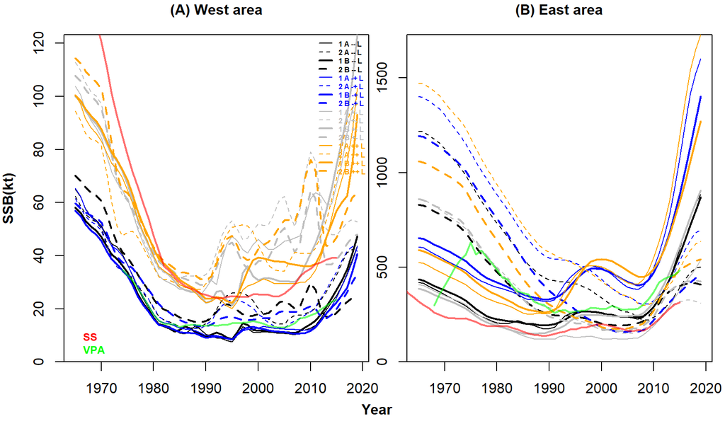

Figure 1. Regional spawning stock comparisons (by area, divisible by 45deg W) with 2017 stock assessment. Note that annual estimates from the operating model are calculated from average of the seasonal predictions.

# 7 Spawning Stock Biomass

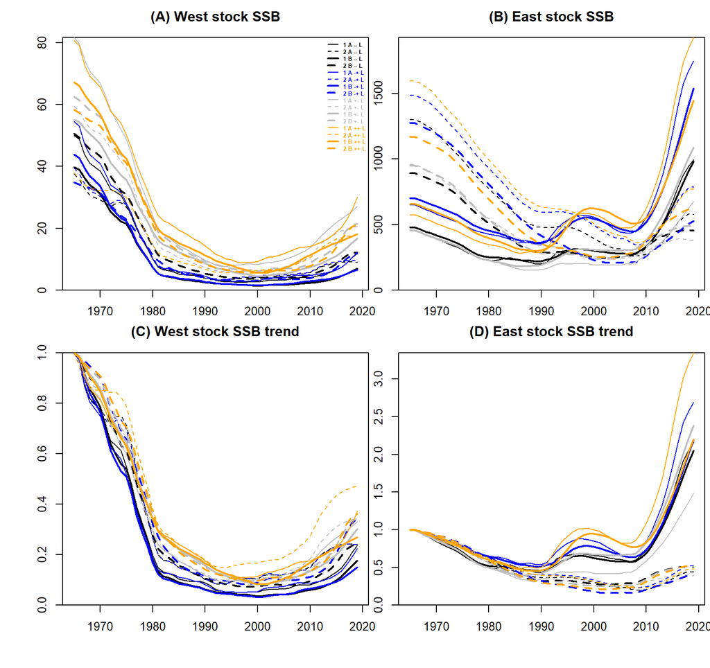

# 8 Spawning stock biomass by stock and area

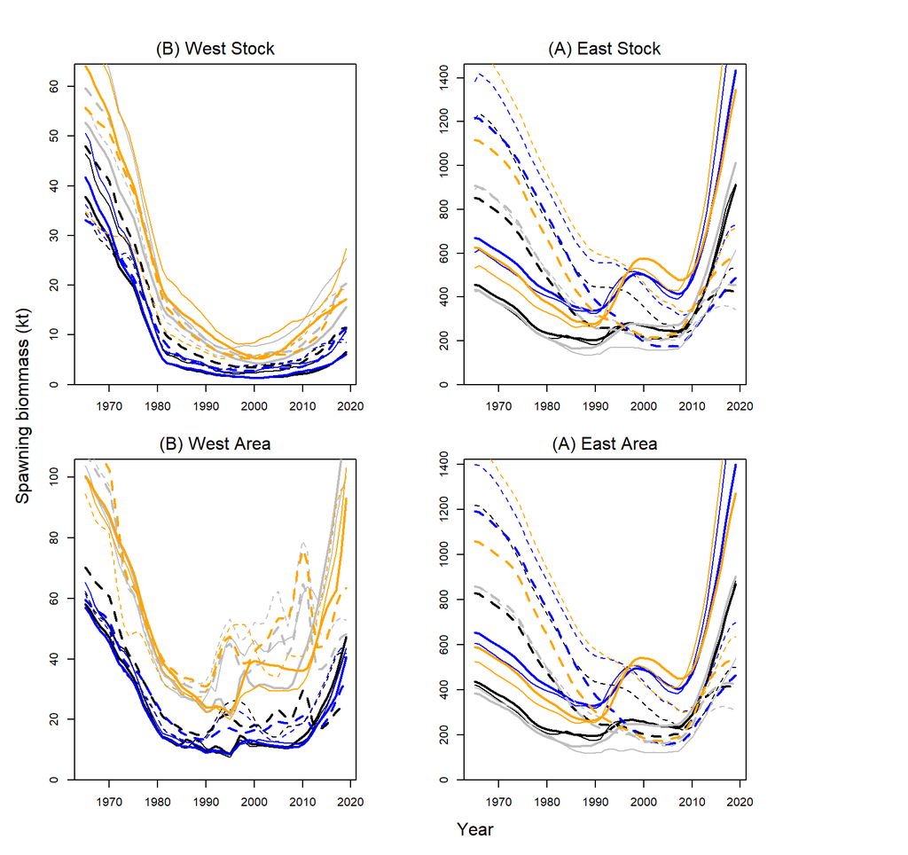

Figure 3. Comparison of stock (top row) and area (bottom row) specific spawning biomass in kilo tonnes.

# 9 SSB relative to dynamic BMSY

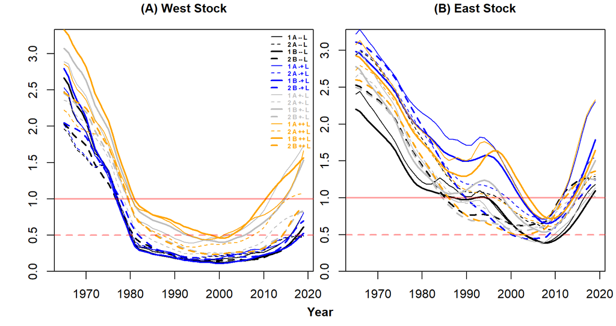

Figure 4. Comparison of stock status estimates (SSB relative to dynamic SSBMSY)

# 10 Stock mixing

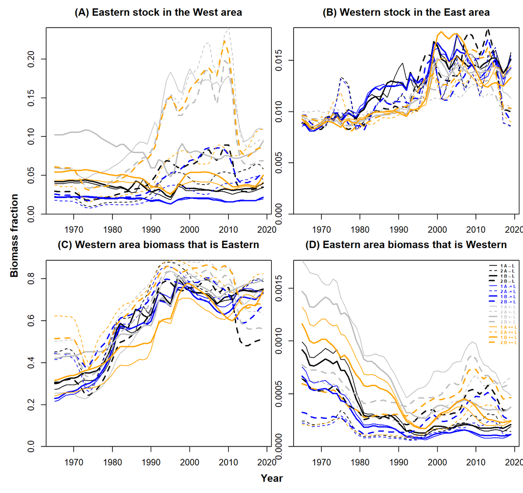

Figure 5a. Biomass fractions by stock (top row) and area (bottom row).

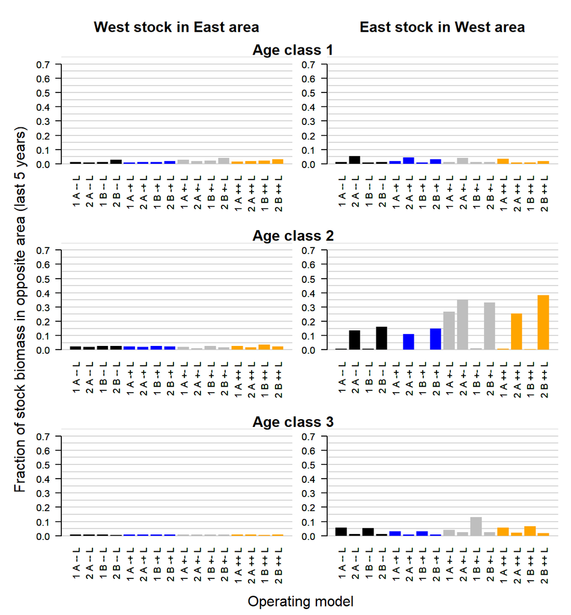

Figure 5b. Fraction of stock biomass in the opposite ocean area (average over last 5 years)(e.g. a value of 0.05 in the top left plot indicates that 5% of the western stock biomass was located in the east Atlantic area over the last 5 years of the historical model fitting)

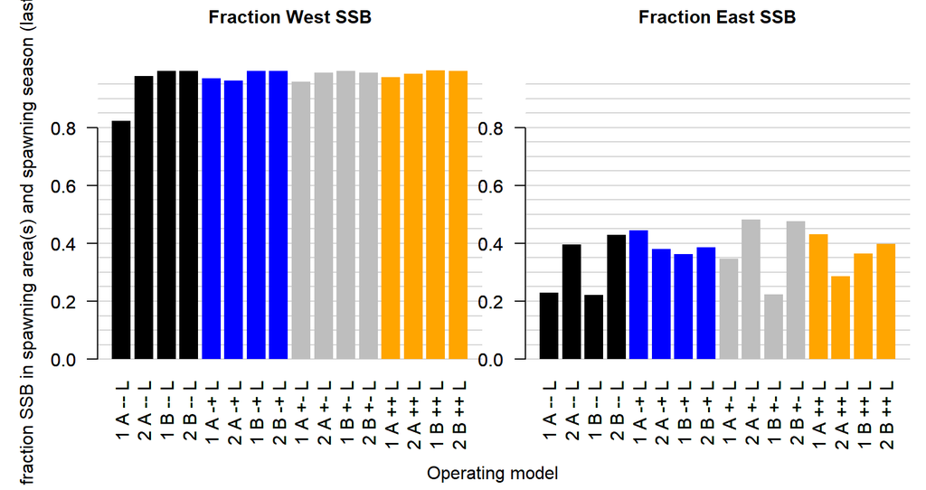

Figure 5c.The mean fraction of stock SSB found in the spawning area and spawning season. CAUTION: these fractions can be hard to interpret. For example, lets consider a case where 100% of eastern fish entered the Mediterranean to spawn and then left after a month. In this case the average fraction would be 1/3 (the spawning season is 3 months long in the model). This may explain why it is not straighforward to link model estimated recruitment to these mean fractions whose principal purpose is to model availability of vulnerably biomass to fishing.

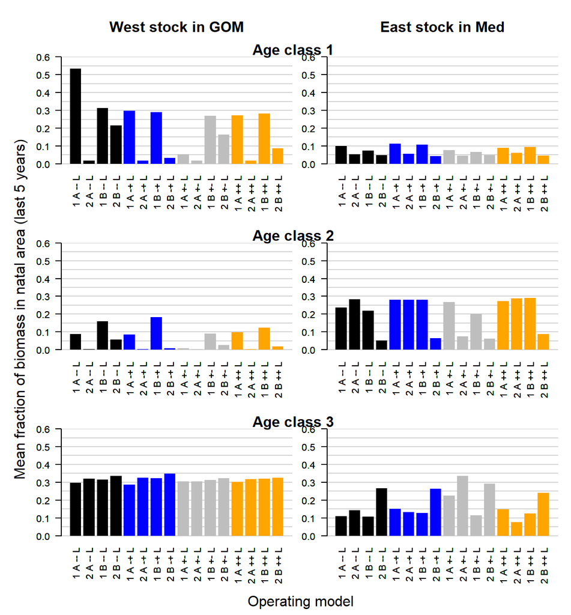

Figure 5d. Fraction of stock biomass in the natal spawning area: Med for the Eastern stock and GOM for the Western stock (average over last 5 years)

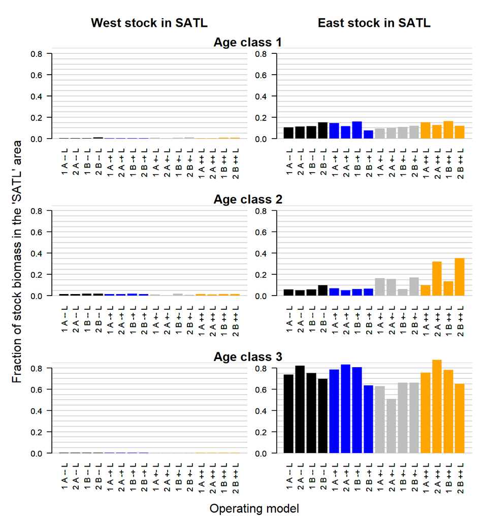

Figure 5e. The mean fraction of stock biomass (by age class) that is found in the so called ‘SATL’ (South Atlantic Area) which includes the East Atlantic waters of southern Spain, Portugal, Gibraltar and Morocco. The model uses these fractions to model availability to fishing so fractions may be estimated to be high if areas are a focal point for feeding or a migration route.

# 11 Fits to stock-specific larval indices

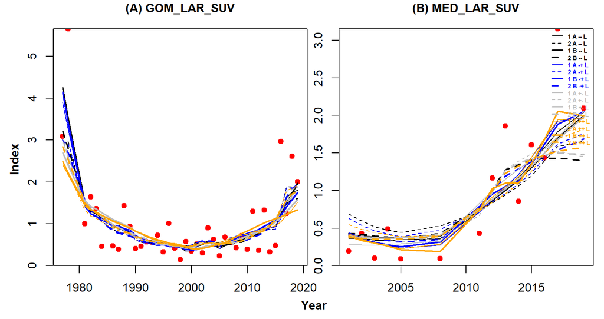

Figure 6. Fits to stock specific larval indices

# 12 Fits to seasonal / spatial priors

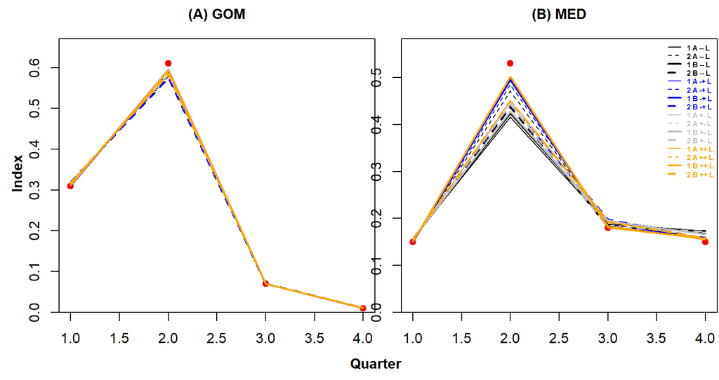

Figure 7. Fit to seasonal-spatial priors (red points are the specified prior medians).

# 13 Fits to aggregate annual catches

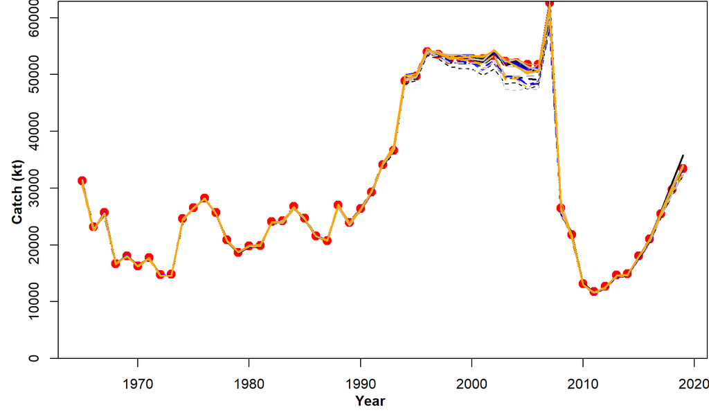

Figure 8. Fits to total annual catches (red points are observed catches).

# 14 Fits to composition data

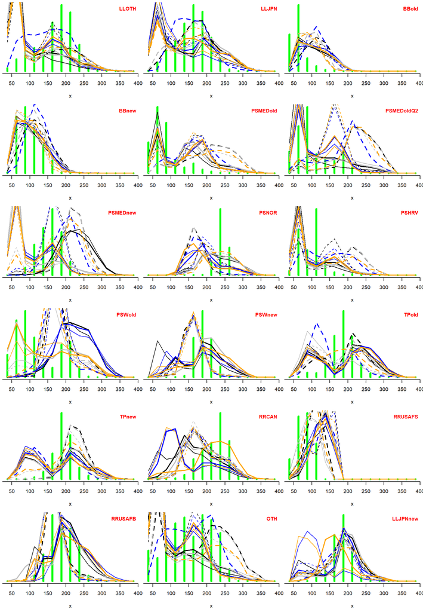

Figure 9. Fits to catch at length composition data.

# 15 Final age structure

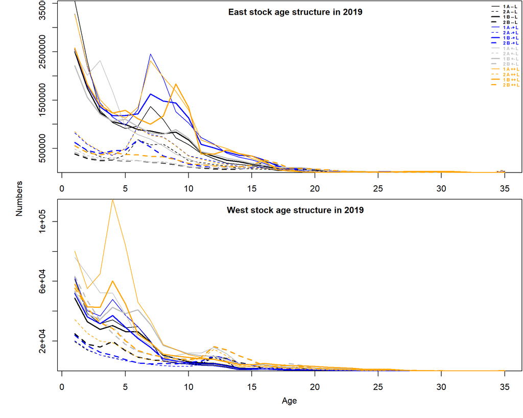

Figure 10a. Final age structure of each stock.

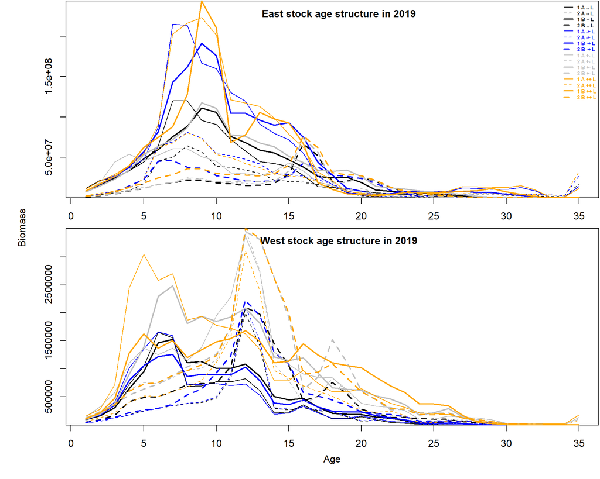

Figure 10b. Biomass-age structure of each stock in the final year of conditioning.

# 16 Summary of aggregated OM estimates

Table 7. Summary of estimate of status, scale and recent trajectory over all operating models

|  | West range | West interquartile | East range | East interquartile |
| --- | --- | --- | --- | --- |
| SSB2016 relative to dyn SSBMSY | 0.37 - 1.46 | 0.49 - 1.05 | 0.82 - 1.92 | 1.06 - 1.27 |
| 2016 SSB (kt) | 4.2 - 21.5 | 7.6 - 15.9 | 359 - 1429.3 | 463.6 - 819.4 |
| SSB trajectory 2007-2016 (% per year) | 5.59 - 15.49 | 10.79 - 14.47 | 7.94 - 25.6 | 10.72 - 20.27 |

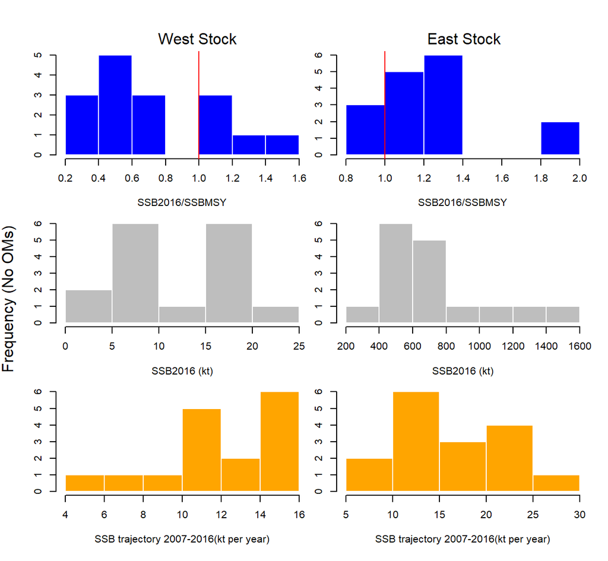

Figure 11. Summary of estimate of status, scale and recent trajectory over all operating models

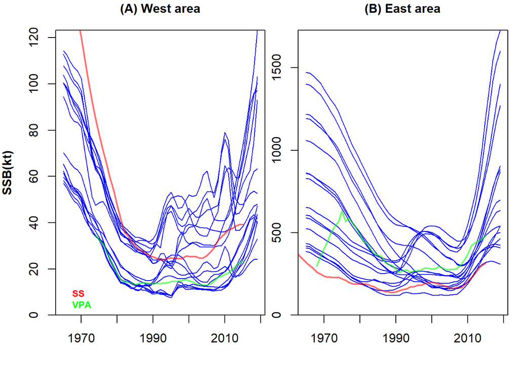

Figure 12. All SSB trajectories by area.